# Tugas Pertemuan 2 - Metode Pemulusan Deret Waktu

30 August 2026

## Deskripsi Data

Data yang digunakan adalah data deret waktu **CES9093161101** bulanan, periode **Juli 1983 - Agustus 1997**, sebanyak **170 observasi** (subset periode 343-512 dari data lengkap).

## Library/Packages

Package yang digunakan pada analisis ini adalah `forecast`, `graphics`, `TTR`, dan `rio`.

```r
library("forecast")
library("graphics")
library("TTR")
library("rio")
library("ggplot2")
```

## Impor Data

```r
data1 <- import("data_saya.xlsx")
head(data1)
```

|  | observation_date | Period | CES9093161101 |
| --- | --- | --- | --- |
| 1 | 1983-07-01 | 343 | 4994.4 |
| 2 | 1983-08-01 | 344 | 5007.8 |
| 3 | 1983-09-01 | 345 | 5018.5 |
| 4 | 1983-10-01 | 346 | 4986.4 |
| 5 | 1983-11-01 | 347 | 5013.9 |
| 6 | 1983-12-01 | 348 | 5013.4 |

## Eksplorasi Data

```r
str(data1)
```

```
## 'data.frame':    170 obs. of  3 variables:
##  $ observation_date: POSIXct, format: "1983-07-01" "1983-08-01" ...
##  $ Period          : num  343 344 345 346 347 348 349 350 351 352 ...
##  $ CES9093161101   : num  4994 5008 5018 4986 5014 ...
```

```r
dim(data1)
```

```
## [1] 170   3
```

```r
data1.ts <- ts(data1$CES9093161101, start = c(1983, 7), frequency = 12)
summary(data1.ts)
```

```
##    Min. 1st Qu.  Median    Mean 3rd Qu.    Max.
##    4986    5439    5923    5858    6272    6768
```

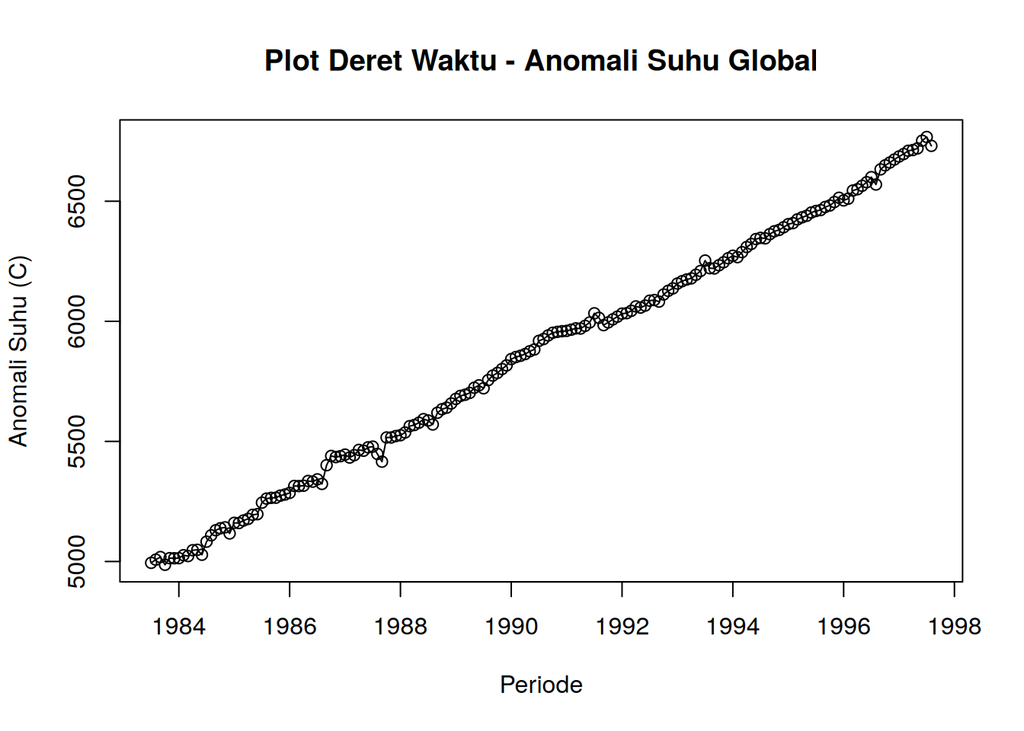

```r
ts.plot(data1.ts, xlab = "Periode", ylab = "Anomali Suhu (C)",
        main = "Plot Deret Waktu - Anomali Suhu Global")
points(data1.ts)
```

Berdasarkan plot di atas, data memperlihatkan pola **tren naik** yang cukup mulus dengan sedikit fluktuasi/noise di sekitarnya, dan tidak menunjukkan pola musiman (seasonal) yang jelas. Karena itu, metode pemulusan musiman (Winter/Holt-Winters musiman) tidak digunakan pada data ini; metode yang diterapkan adalah **SMA, DMA, SES, dan DES**.

## Pembagian Data

Data dibagi menjadi 80% data latih dan 20% data uji.

```r
n <- nrow(data1)
n_train <- floor(0.8 * n)

training <- data1[1:n_train, ]
testing  <- data1[(n_train + 1):n, ]

train.ts <- ts(training$CES9093161101, start = c(1983, 7), frequency = 12)
test.ts  <- ts(testing$CES9093161101,
                start = time(train.ts)[length(train.ts)] + 1/12,
                frequency = 12)

n_train
```

```
## [1] 136
```

```r
n - n_train
```

```
## [1] 34
```

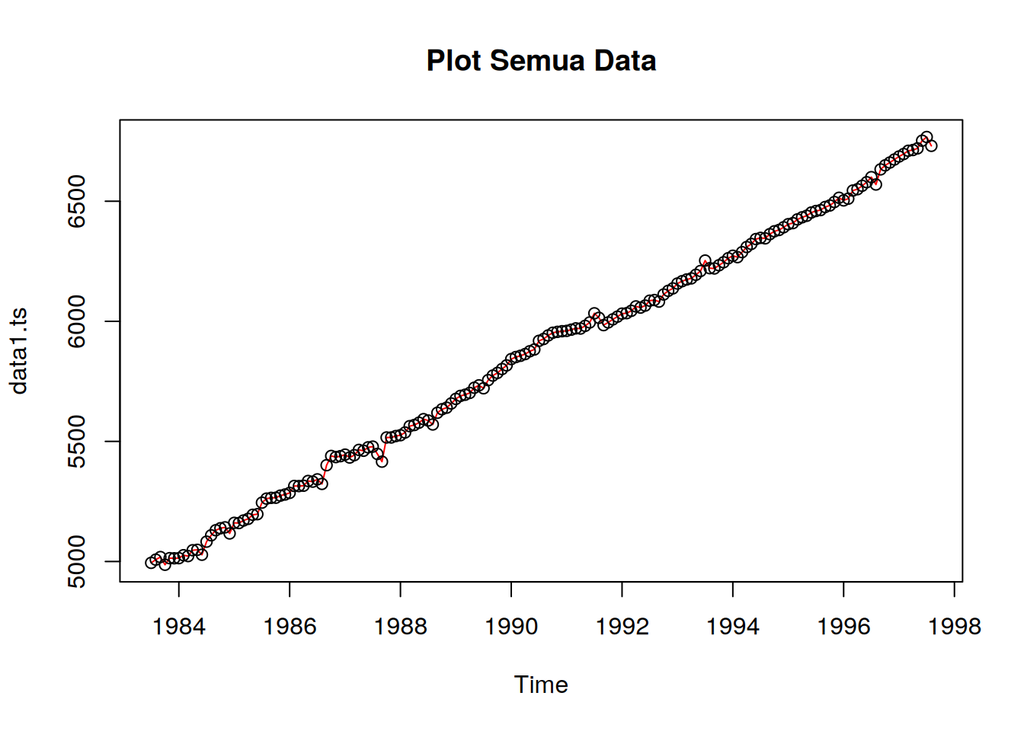

```r
plot(data1.ts, col = "red", main = "Plot Semua Data")
points(data1.ts)
```

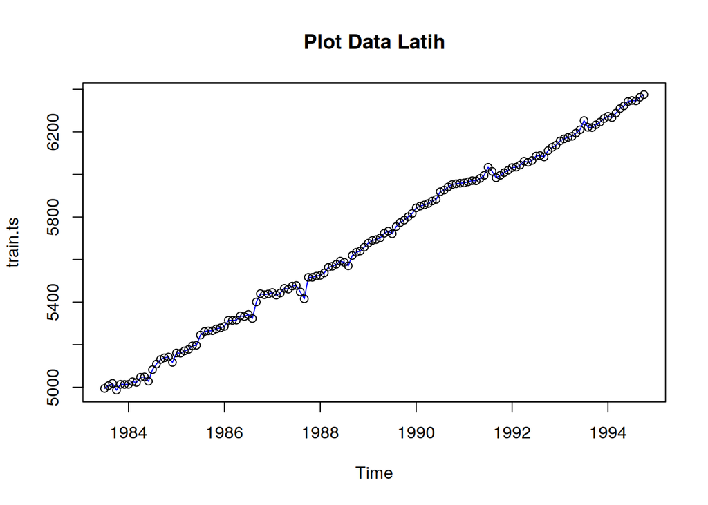

```r
plot(train.ts, col = "blue", main = "Plot Data Latih")
points(train.ts)
```

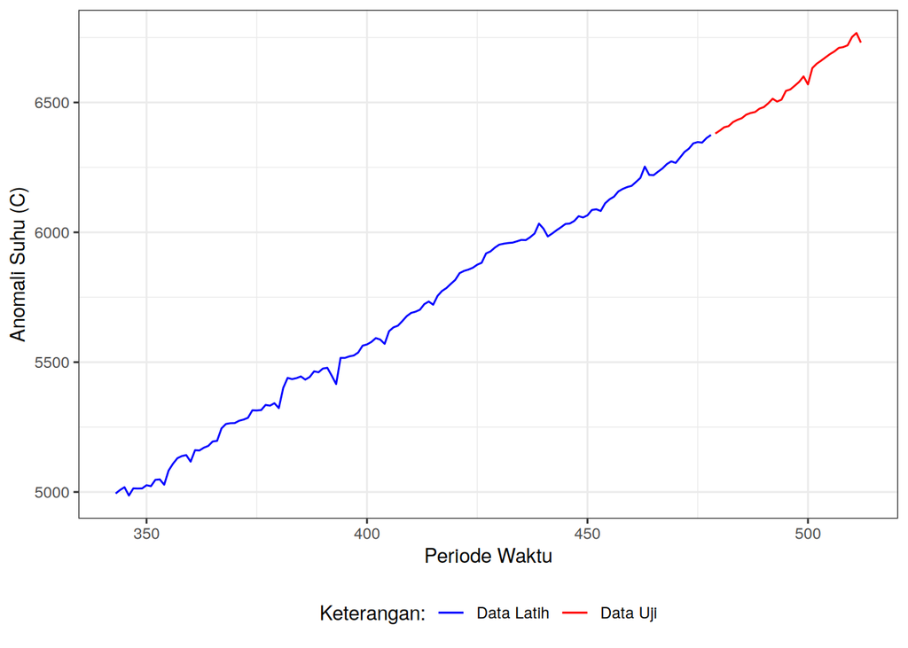

```r
ggplot() +
  geom_line(data = training, aes(x = Period, y = CES9093161101, col = "Data Latih")) +
  geom_line(data = testing, aes(x = Period, y = CES9093161101, col = "Data Uji")) +
  labs(x = "Periode Waktu", y = "Anomali Suhu (C)", color = "Legend") +
  scale_colour_manual(name = "Keterangan:", breaks = c("Data Latih", "Data Uji"),
                       values = c("blue", "red")) +
  theme_bw() + theme(legend.position = "bottom",
                      plot.caption = element_text(hjust = 0.5, size = 12))
```

## Metode 1: Single Moving Average (SMA)

```r
data.sma <- SMA(train.ts, n = 4)
data.sma
```

```
##           Jan      Feb      Mar      Apr      May      Jun      Jul      Aug
## 1983                                                             NA       NA
## 1984 5006.875 5016.825 5018.975 5027.350 5036.075 5036.550 5051.575 5067.100
## 1985 5139.600 5145.000 5152.125 5167.300 5175.675 5184.925 5203.500 5224.600
## 1986 5276.125 5288.400 5298.300 5307.450 5319.850 5324.300 5331.300 5333.175
## 1987 5439.425 5437.775 5439.800 5446.350 5450.375 5461.000 5469.875 5465.675
## 1988 5520.225 5525.400 5537.175 5548.675 5561.700 5575.600 5581.475 5582.025
## 1989 5652.350 5666.250 5679.725 5690.700 5702.325 5713.300 5720.025 5733.350
## 1990 5811.475 5828.000 5841.800 5853.550 5861.675 5869.525 5885.075 5900.775
## 1991 5956.925 5960.125 5963.750 5966.525 5971.750 5979.275 5994.950 6006.100
## 1992 6013.775 6023.400 6032.300 6042.950 6049.200 6057.100 6067.675 6074.325
## 1993 6133.275 6147.125 6158.925 6169.350 6178.475 6189.100 6208.800 6219.400
## 1994 6253.775 6262.225 6272.750 6284.400 6296.675 6315.500 6330.375 6339.400
##           Sep      Oct      Nov      Dec
## 1983       NA 5001.775 5006.650 5008.050
## 1984 5087.475 5115.050 5129.950 5131.900
## 1985 5242.225 5259.350 5266.700 5270.950
## 1986 5349.575 5376.350 5399.525 5428.400
## 1987 5454.325 5464.575 5474.100 5492.700
## 1988 5592.350 5602.675 5616.025 5637.900
## 1989 5745.975 5758.900 5778.925 5794.275
## 1990 5917.250 5934.700 5944.075 5952.175
## 1991 6006.850 6006.850 6000.525 6001.775
## 1992 6080.575 6092.125 6102.375 6114.475
## 1993 6225.975 6231.925 6230.150 6240.525
## 1994 6349.575 6357.675
```

```r
data.ramal.sma <- c(NA, data.sma)
forecast.sma <- rep(data.ramal.sma[length(data.ramal.sma)], length(test.ts) - 1)

data.gab.sma <- cbind(
  aktual = c(data1.ts),
  pemulusan = c(data.sma, rep(NA, length(test.ts))),
  ramalan = c(data.ramal.sma, rep(data.ramal.sma[length(data.ramal.sma)], length(test.ts) - 1))
)
data.gab.sma
```

```
##        aktual pemulusan  ramalan
##   [1,] 4994.4        NA       NA
##   [2,] 5007.8        NA       NA
##   [3,] 5018.5        NA       NA
##   [4,] 4986.4  5001.775       NA
##   [5,] 5013.9  5006.650 5001.775
##   [6,] 5013.4  5008.050 5006.650
##   [7,] 5013.8  5006.875 5008.050
##   [8,] 5026.2  5016.825 5006.875
##   [9,] 5022.5  5018.975 5016.825
##  [10,] 5046.9  5027.350 5018.975
##  [11,] 5048.7  5036.075 5027.350
##  [12,] 5028.1  5036.550 5036.075
##  [13,] 5082.6  5051.575 5036.550
##  [14,] 5109.0  5067.100 5051.575
```

[output cut: 156 more lines]

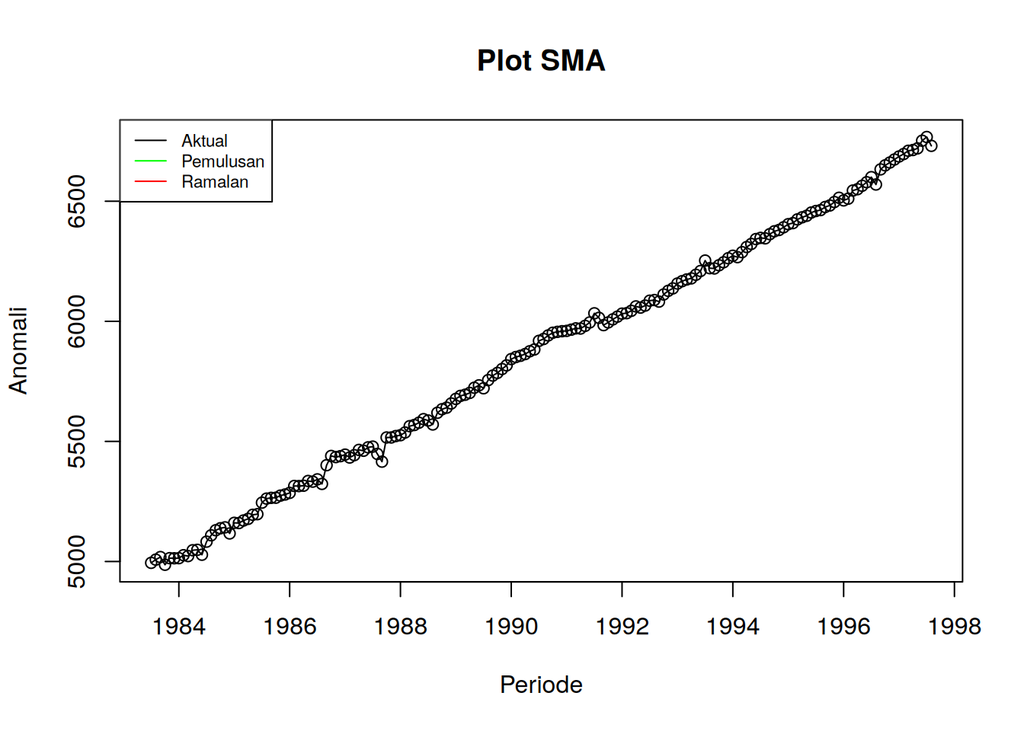

```r
ts.plot(data1.ts, xlab = "Periode", ylab = "Anomali",
        main = "Plot SMA")
points(data1.ts)
lines(data.gab.sma[,2], col = "green", lwd = 2)
lines(data.gab.sma[,3], col = "red", lwd = 2)
legend("topleft", c("Aktual", "Pemulusan", "Ramalan"),
       lty = 1, col = c("black", "green", "red"), cex = 0.7)
```

### Akurasi Data Latih - SMA

```r
error_train.sma <- train.ts - data.ramal.sma[1:length(train.ts)]
SSE_train.sma <- sum(error_train.sma[5:length(train.ts)]^2)
MSE_train.sma <- mean(error_train.sma[5:length(train.ts)]^2)
MAPE_train.sma <- mean(abs(error_train.sma[5:length(train.ts)]/train.ts[5:length(train.ts)])) * 100

akurasi_train.sma <- matrix(c(SSE_train.sma, MSE_train.sma, MAPE_train.sma))
row.names(akurasi_train.sma) <- c("SSE", "MSE", "MAPE")
colnames(akurasi_train.sma) <- "Akurasi Data Latih SMA"
akurasi_train.sma
```

```
##      Akurasi Data Latih SMA
## SSE            1.372162e+05
## MSE            1.039517e+03
## MAPE           4.959181e-01
```

### Akurasi Data Uji - SMA

```r
error_test.sma <- test.ts - data.gab.sma[(n_train+1):n, 3]
SSE_test.sma <- sum(error_test.sma^2)
MSE_test.sma <- mean(error_test.sma^2)
MAPE_test.sma <- mean(abs(error_test.sma/test.ts)) * 100

akurasi_test.sma <- matrix(c(SSE_test.sma, MSE_test.sma, MAPE_test.sma))
row.names(akurasi_test.sma) <- c("SSE", "MSE", "MAPE")
colnames(akurasi_test.sma) <- "Akurasi Data Uji SMA"
akurasi_test.sma
```

```
##      Akurasi Data Uji SMA
## SSE          1.859627e+06
## MSE          5.469491e+04
## MAPE         3.054625e+00
```

## Metode 2: Double Moving Average (DMA)

```r
dma <- SMA(data.sma, n = 4)
At <- 2 * data.sma - dma
Bt <- 2 / (4 - 1) * (data.sma - dma)
data.dma <- At + Bt
data.ramal2.dma <- c(NA, data.dma)

h <- length(test.ts)
f <- c()
for (i in 1:h) {
  f[i] <- At[length(At)] + Bt[length(Bt)] * i
}

data.gab2.dma <- cbind(
  aktual = c(data1.ts),
  pemulusan1 = c(data.sma, rep(NA, h)),
  pemulusan2 = c(dma, rep(NA, h)),
  At = c(At, rep(NA, h)),
  Bt = c(Bt, rep(NA, h)),
  ramalan = c(data.ramal2.dma, f[-1])
)
data.gab2.dma
```

```
##        aktual pemulusan1 pemulusan2       At         Bt  ramalan
##   [1,] 4994.4         NA         NA       NA         NA       NA
##   [2,] 5007.8         NA         NA       NA         NA       NA
##   [3,] 5018.5         NA         NA       NA         NA       NA
##   [4,] 4986.4   5001.775         NA       NA         NA       NA
##   [5,] 5013.9   5006.650         NA       NA         NA       NA
##   [6,] 5013.4   5008.050         NA       NA         NA       NA
##   [7,] 5013.8   5006.875   5005.837 5007.913  0.6916667       NA
##   [8,] 5026.2   5016.825   5009.600 5024.050  4.8166667 5008.604
##   [9,] 5022.5   5018.975   5012.681 5025.269  4.1958333 5028.867
##  [10,] 5046.9   5027.350   5017.506 5037.194  6.5625000 5029.465
##  [11,] 5048.7   5036.075   5024.806 5047.344  7.5125000 5043.756
##  [12,] 5028.1   5036.550   5029.737 5043.363  4.5416667 5054.856
##  [13,] 5082.6   5051.575   5037.887 5065.263  9.1250000 5047.904
##  [14,] 5109.0   5067.100   5047.825 5086.375 12.8500000 5074.388
```

[output cut: 156 more lines]

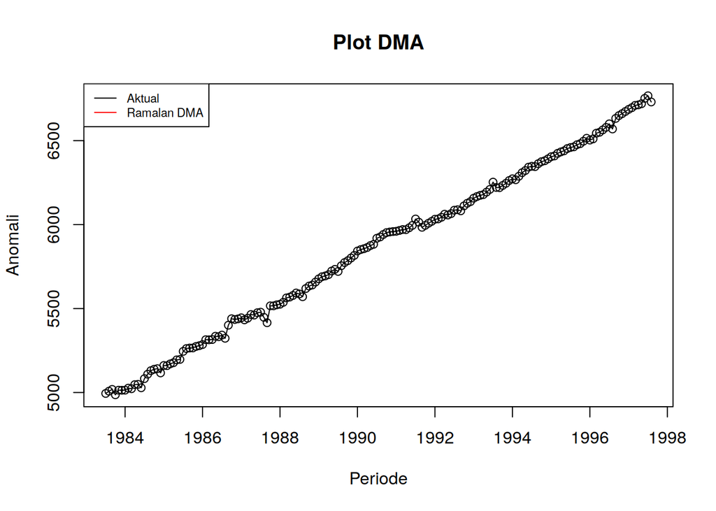

```r
ts.plot(data1.ts, xlab = "Periode", ylab = "Anomali",
        main = "Plot DMA")
points(data1.ts)
lines(data.gab2.dma[,6], col = "red", lwd = 2)
legend("topleft", c("Aktual", "Ramalan DMA"),
       lty = 1, col = c("black", "red"), cex = 0.7)
```

### Akurasi Data Latih - DMA

```r
error_train.dma <- train.ts - data.ramal2.dma[1:length(train.ts)]
SSE_train.dma <- sum(error_train.dma[8:length(train.ts)]^2)
MSE_train.dma <- mean(error_train.dma[8:length(train.ts)]^2)
MAPE_train.dma <- mean(abs(error_train.dma[8:length(train.ts)]/train.ts[8:length(train.ts)])) * 100

akurasi_train.dma <- matrix(c(SSE_train.dma, MSE_train.dma, MAPE_train.dma))
row.names(akurasi_train.dma) <- c("SSE", "MSE", "MAPE")
colnames(akurasi_train.dma) <- "Akurasi Data Latih DMA"
akurasi_train.dma
```

```
##      Akurasi Data Latih DMA
## SSE            6.750321e+04
## MSE            5.232807e+02
## MAPE           2.985929e-01
```

### Akurasi Data Uji - DMA

```r
error_test.dma <- test.ts - data.gab2.dma[(n_train+1):n, 6]
SSE_test.dma <- sum(error_test.dma^2)
MSE_test.dma <- mean(error_test.dma^2)
MAPE_test.dma <- mean(abs(error_test.dma/test.ts)) * 100

akurasi_test.dma <- matrix(c(SSE_test.dma, MSE_test.dma, MAPE_test.dma))
row.names(akurasi_test.dma) <- c("SSE", "MSE", "MAPE")
colnames(akurasi_test.dma) <- "Akurasi Data Uji DMA"
akurasi_test.dma
```

```
##      Akurasi Data Uji DMA
## SSE          7.150943e+04
## MSE          2.103219e+03
## MAPE         4.913342e-01
```

## Metode 3: Single Exponential Smoothing (SES)

SES cocok untuk data tanpa tren, namun tetap dicobakan sebagai pembanding. Digunakan nilai alpha optimum (dipilih otomatis oleh fungsi `ses()`).

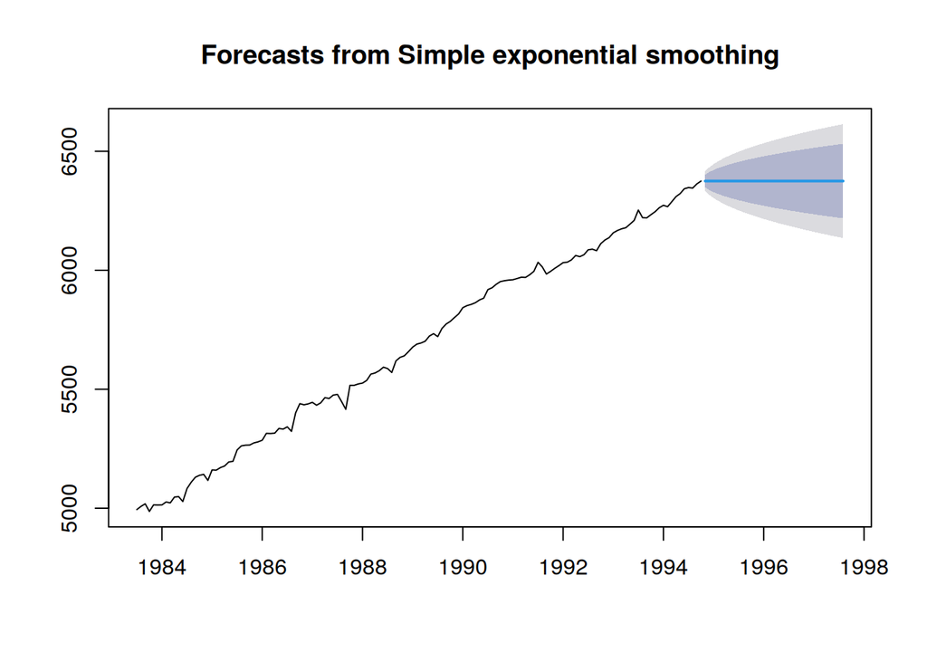

```r
ses.opt <- ses(train.ts, h = length(test.ts), alpha = NULL)
plot(ses.opt)
```

```r
ses.opt$model
```

```
## Simple exponential smoothing
##
## Call:
##  ses(y = train.ts, h = length(test.ts), alpha = NULL)
##
##   Smoothing parameters:
##     alpha = 0.9999
##
##   Initial states:
##     l = 4994.3681
##
##   sigma:  20.958
##
##      AIC     AICc      BIC
## 1499.671 1499.853 1508.409
```

### Akurasi Data Latih - SES

```r
ses.fitted <- ses.opt$fitted
error_train.ses <- train.ts - ses.fitted
SSE_train.ses <- sum(error_train.ses^2)
MSE_train.ses <- mean(error_train.ses^2)
MAPE_train.ses <- mean(abs(error_train.ses/train.ts)) * 100

akurasi_train.ses <- matrix(c(SSE_train.ses, MSE_train.ses, MAPE_train.ses))
row.names(akurasi_train.ses) <- c("SSE", "MSE", "MAPE")
colnames(akurasi_train.ses) <- "Akurasi Data Latih SES"
akurasi_train.ses
```

```
##      Akurasi Data Latih SES
## SSE            5.885768e+04
## MSE            4.327770e+02
## MAPE           2.655361e-01
```

### Akurasi Data Uji - SES

```r
ses.forecast <- as.numeric(ses.opt$mean)
error_test.ses <- test.ts - ses.forecast
SSE_test.ses <- sum(error_test.ses^2)
MSE_test.ses <- mean(error_test.ses^2)
MAPE_test.ses <- mean(abs(error_test.ses/test.ts)) * 100

akurasi_test.ses <- matrix(c(SSE_test.ses, MSE_test.ses, MAPE_test.ses))
row.names(akurasi_test.ses) <- c("SSE", "MSE", "MAPE")
colnames(akurasi_test.ses) <- "Akurasi Data Uji SES"
akurasi_test.ses
```

```
##      Akurasi Data Uji SES
## SSE          1.632650e+06
## MSE          4.801912e+04
## MAPE         2.791987e+00
```

## Metode 4: Double Exponential Smoothing (DES)

Karena data memiliki pola tren, DES (Holt’s method dengan trend, tanpa musiman) diperkirakan lebih sesuai dibanding SES. Digunakan alpha dan beta optimum.

```r
des.opt <- HoltWinters(train.ts, gamma = FALSE)
des.opt
```

```
## Holt-Winters exponential smoothing with trend and without seasonal component.
##
## Call:
## HoltWinters(x = train.ts, gamma = FALSE)
##
## Smoothing parameters:
##  alpha: 0.6939314
##  beta : 0.01537296
##  gamma: FALSE
##
## Coefficients:
##         [,1]
## a 6374.19333
## b   10.58946
```

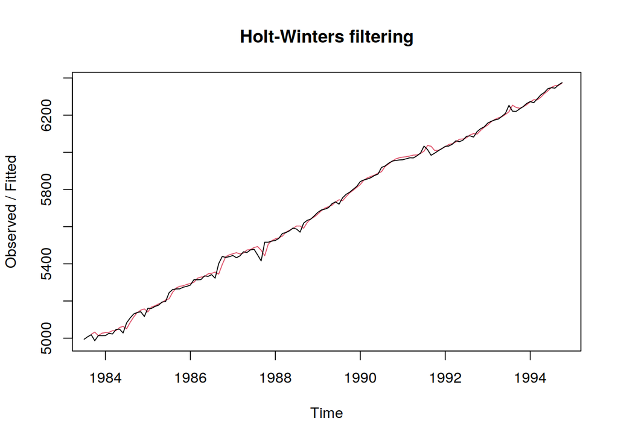

```r
plot(des.opt)
```

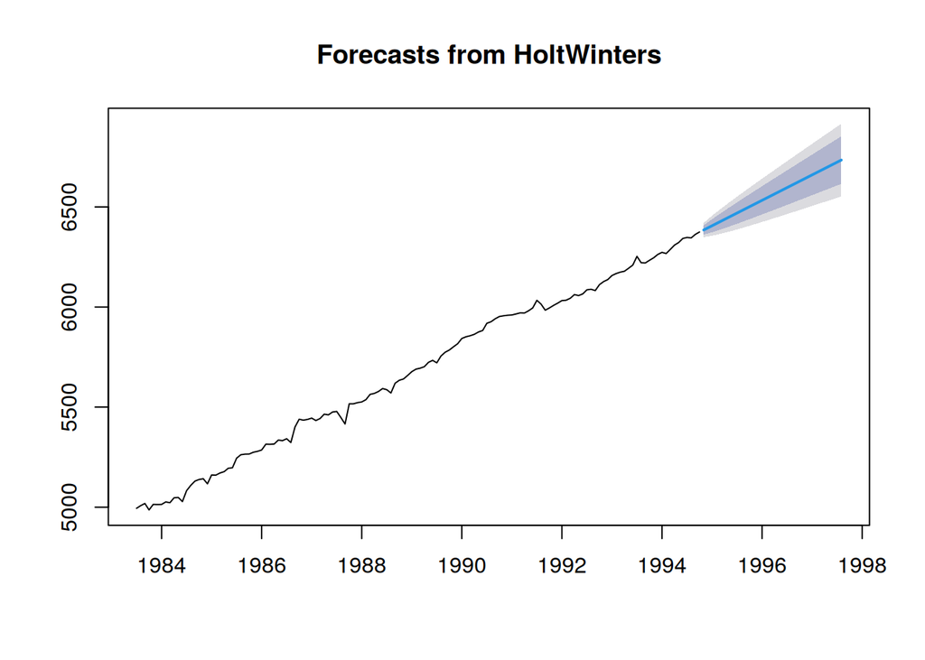

```r
ramalan.des <- forecast(des.opt, h = length(test.ts))
plot(ramalan.des)
```

### Akurasi Data Latih - DES

```r
des.fitted <- des.opt$fitted[,1]
error_train.des <- train.ts[-(1:2)] - des.fitted
SSE_train.des <- sum(error_train.des^2)
MSE_train.des <- mean(error_train.des^2)
MAPE_train.des <- mean(abs(error_train.des/train.ts[-(1:2)])) * 100

akurasi_train.des <- matrix(c(SSE_train.des, MSE_train.des, MAPE_train.des))
row.names(akurasi_train.des) <- c("SSE", "MSE", "MAPE")
colnames(akurasi_train.des) <- "Akurasi Data Latih DES"
akurasi_train.des
```

```
##      Akurasi Data Latih DES
## SSE            4.342471e+04
## MSE            3.240650e+02
## MAPE           2.247134e-01
```

### Akurasi Data Uji - DES

```r
des.forecast <- as.numeric(ramalan.des$mean)
error_test.des <- test.ts - des.forecast
SSE_test.des <- sum(error_test.des^2)
MSE_test.des <- mean(error_test.des^2)
MAPE_test.des <- mean(abs(error_test.des/test.ts)) * 100

akurasi_test.des <- matrix(c(SSE_test.des, MSE_test.des, MAPE_test.des))
row.names(akurasi_test.des) <- c("SSE", "MSE", "MAPE")
colnames(akurasi_test.des) <- "Akurasi Data Uji DES"
akurasi_test.des
```

```
##      Akurasi Data Uji DES
## SSE          1.352720e+04
## MSE          3.978587e+02
## MAPE         2.485717e-01
```

## Perbandingan Metode & Kesimpulan

```r
perbandingan <- data.frame(
  Metode = c("SMA (m=4)", "DMA (m=4)", "SES (alpha optimum)", "DES (Holt, alpha & beta optimum)"),
  SSE_Latih = c(SSE_train.sma, SSE_train.dma, SSE_train.ses, SSE_train.des),
  MSE_Latih = c(MSE_train.sma, MSE_train.dma, MSE_train.ses, MSE_train.des),
  MAPE_Latih = c(MAPE_train.sma, MAPE_train.dma, MAPE_train.ses, MAPE_train.des),
  SSE_Uji = c(SSE_test.sma, SSE_test.dma, SSE_test.ses, SSE_test.des),
  MSE_Uji = c(MSE_test.sma, MSE_test.dma, MSE_test.ses, MSE_test.des),
  MAPE_Uji = c(MAPE_test.sma, MAPE_test.dma, MAPE_test.ses, MAPE_test.des)
)
knitr::kable(perbandingan, digits = 4)
```

| Metode | SSE_Latih | MSE_Latih | MAPE_Latih | SSE_Uji | MSE_Uji | MAPE_Uji |
| --- | --- | --- | --- | --- | --- | --- |
| SMA (m=4) | 137216.25 | 1039.5170 | 0.4959 | 1859626.77 | 54694.9050 | 3.0546 |
| DMA (m=4) | 67503.21 | 523.2807 | 0.2986 | 71509.43 | 2103.2186 | 0.4913 |
| SES (alpha optimum) | 58857.68 | 432.7770 | 0.2655 | 1632649.99 | 48019.1174 | 2.7920 |
| DES (Holt, alpha & beta optimum) | 43424.71 | 324.0650 | 0.2247 | 13527.20 | 397.8587 | 0.2486 |

```r
terbaik <- perbandingan$Metode[which.min(perbandingan$MAPE_Uji)]
terbaik
```

```
## [1] "DES (Holt, alpha & beta optimum)"
```

Metode terbaik dipilih berdasarkan nilai **MAPE data uji terkecil** (karena MAPE tidak bergantung pada satuan/skala data sehingga lebih adil untuk dibandingkan antar metode).

Berdasarkan tabel perbandingan di atas, metode dengan MAPE data uji terkecil adalah metode yang dipilih sebagai metode pemulusan terbaik untuk data ini, yaitu **DES (Holt, alpha & beta optimum)** (lihat objek `terbaik`).

Beberapa catatan penting dari hasil di atas:

- Metode dengan komponen tren (DMA dan DES) umumnya membantu mengikuti pergerakan naik pada data dibandingkan metode SMA/SES yang cenderung tertinggal di belakang tren.
- Nilai smoothing parameter (alpha, beta) yang terpilih secara otomatis oleh `ses()` dan `HoltWinters()` mencerminkan seberapa besar bobot yang diberikan pada observasi terbaru versus histori data.
- Perbandingan MAPE data uji antar metode memberikan gambaran metode mana yang paling sesuai untuk peramalan jangka pendek pada data ini.

**Kesimpulan:** metode **DES (Holt, alpha & beta optimum)** dipilih sebagai metode pemulusan terbaik untuk data ini karena memberikan SSE, MSE, dan MAPE data uji yang paling kecil di antara SMA, DMA, SES, dan DES.